# R instead of GIS

Using RStudio for location data analytics

Ryan Garnett

### 1.0 Overview

Analyzing, evaluating and visualizing geographic data is a common requirement within municipal governments. Typically these tasks have been undertaken within commercial or open source GIS software application (i.e. ArcMap, GRASS, MapInfo, QGIS, etc.). GIS applications are typically graphic user interfaces (GUI) that are comprised of a number of tools that can be used to perform analysis and visualization tasks.

R is an open source language that is typically considered to be used for statistical analysis. As a language R has been around for approximately 25 years, experiencing significant advancements. R Studios is a GUI based interface to R that allows for analysis, visualization, modelling, and more.

Within the domain of GIS R provides an excellent platform for data analysis, exploration, modelling, and visualization. The R community is very active in the development and advancement of geospatial packages (tools/libraries) that are available. This workshop will focus on providing an introduction to the understanding of capabilities of using R Studios as a GIS application. Within the workshop examples will focus on vector data, specifically around visualization, data exploration, and geoprocessing.

### 2.0 Prerequisites

R Studio, similar to other software application, has the capability to extend functionality via add-ins. Within the world of R add-ins are called “packages”. A package is similar to a library in other programming languages (i.e. Python), or extensions in GIS applications (i.e. ArcMap or QGIS).

*tidyverse*

The tidyverse is an opinionated collection of R packages designed for data science. All packages share an underlying design philosophy, grammar, and data structures. The core tidyverse includes the packages that you’re likely to use in everyday data analyses. As of tidyverse 1.2.0, the following packages are included in the core tidyverse:

- ggplot2
- dplyr
- tidyr
- readr
- purrr
- tibble
- stringr
- forcats

*sf*

Support for simple features, a standardized way to encode spatial vector data. Binds to ‘GDAL’ for reading and writing data, to ‘GEOS’ for geometrical operations, and to ‘PROJ’ for projection conversions and datum transformations.

*mapview*

An R package created to help researchers during their spatial data analysis workflow. It provides functions to very quickly and conveniently create interactive visualizations of spatial data. It was created to fill the gap of quick (not presentation grade) interactive plotting to examine and visually investigate both aspects of spatial data, the geometries and their attributes.

#### 2.1 Packages

```r
library(tidyverse)
library(sf)
library(mapview)
```

#### 2.2 Loading Vector Data

```r
# Data downloaded from City of Toronto's Open Data Catalog
# https://www.toronto.ca/city-government/data-research-maps/open-data/open-data-catalogue/
# Load vector (shapefile) information
setwd("C:/WorkDocs/rGIS/vector")
```

```
The working directory was changed to C:/WorkDocs/rGIS/vector inside a notebook chunk. The working directory will be reset when the chunk is finished running. Use the knitr root.dir option in the setup chunk to change the working directory for notebook chunks.
```

```r
schools <- st_read("SCHOOL.shp")
subway <- st_read("TTC_SUBWAY_LINES.shp")
wards <- st_read("WARD.shp")
#schools download url: http://opendata.toronto.ca/gcc/school_frm_police_mtm3.zip
#subway download url: http://opendata.toronto.ca/gcc/TTC_subway%20lines_mtm3.zip
#wards download url: http://opendata.toronto.ca/gcc/WARD25_OpenData_08072018_mtm3.zip
```

### 3.0 Exploring Data

Within most analytics projects, prior to performing analysis, there is a need to explore the data. Typically this involves looking at the attribute information, assessing for quality, trends, unique values, and determining if new attributes should be created. With location data there is another element that can be explored, the geometry. Within this section data exploration techniques, both attribute and geometry, will covered.

#### 3.1 Exploring Attributes

One of the first steps inthe data exploration phase is to understand the structure of the attribute data, specifically knowing the column names and their data type (i.e. string, number, date, etc.). The *str* function will return the structure of the data table.

```r
#Explore schools data
#View the structure of the data
str(schools)
```

```
Classes ‘sf’ and 'data.frame':  1130 obs. of  26 variables:
 $ NAME      : Factor w/ 1130 levels "A G B U ZAROUKIAN",..: 122 123 124 125 127 129 130 131 133 134 ...
 $ SCL_LVL   : Factor w/ 0 levels: NA NA NA NA NA NA NA NA NA NA ...
 $ SCL_TP    : Factor w/ 7 levels "C","EP","ES",..: 3 2 2 2 2 2 2 2 2 2 ...
 $ BRD_NAME  : Factor w/ 4 levels "Conseil scolaire de district catholique Centre-Sud",..: 3 4 4 4 4 4 4 4 4 4 ...
 $ SCL_TP_DSC: Factor w/ 7 levels "College","English Public",..: 3 2 2 2 2 2 2 2 2 2 ...
 $ ADD_PT_ID : num  565242 11467213 8344927 312084 313306 ...
 $ ADD_NUM   : Factor w/ 473 levels "1","1 1/2","10",..: 144 463 389 389 80 330 10 458 455 414 ...
 $ LN_NAM_FUL: Factor w/ 736 levels "Albion Rd","Alexander St",..: 645 85 705 87 91 163 92 430 165 97 ...
 $ ADD_FULL  : Factor w/ 1071 levels "1 1/2 Garfield Ave",..: 381 1050 888 875 224 735 72 1044 1035 934 ...
 $ POSTAL_CD : Factor w/ 1013 levels "M1B 1B3","M1B 1H3",..: 312 280 934 199 207 930 352 773 764 810 ...
 $ MUN       : Factor w/ 6 levels "East York","Etobicoke",..: 4 4 2 5 5 2 4 3 3 4 ...
 $ CITY      : Factor w/ 1 level "Toronto": 1 1 1 1 1 1 1 1 1 1 ...
 $ GEN_USE_CD: int  102004 102001 102001 102001 102001 102001 102001 102001 102002 102001 ...
 $ CNTL_ID   : num  14228166 11467035 8344924 14198001 103922 ...
 $ LO_NUM    : int  211 95 60 60 151 45 106 93 90 70 ...
 $ LO_NUM_SUF: Factor w/ 2 levels "1/2","A": NA NA NA NA NA NA NA NA NA NA ...
 $ HI_NUM    : int  0 0 0 0 0 0 0 0 0 0 ...
 $ HI_NUM_SUF: Factor w/ 0 levels: NA NA NA NA NA NA NA NA NA NA ...
 $ LN_NAM_ID : num  6792 5028 2752 7427 7438 ...
 $ X         : num  312586 318323 298326 319668 322959 ...
 $ Y         : num  4851066 4848876 4836061 4848776 4852218 ...
 $ LATITUDE  : num  43.8 43.8 43.7 43.8 43.8 ...
 $ LONGITUDE : num  -79.4 -79.3 -79.6 -79.3 -79.3 ...
 $ OBJECTID  : num  3075317 2985494 3837769 2527855 2225897 ...
 $ RID       : num  1 2 3 4 5 6 7 8 9 10 ...
 $ geometry  :sfc_POINT of length 1130; first list element: Classes 'XY', 'POINT', 'sfg'  num [1:2] 312586 4851066
 - attr(*, "sf_column")= chr "geometry"
 - attr(*, "agr")= Factor w/ 3 levels "constant","aggregate",..: NA NA NA NA NA NA NA NA NA NA ...
  ..- attr(*, "names")= chr  "NAME" "SCL_LVL" "SCL_TP" "BRD_NAME" ...
```

```r
#Unique attributes of a column
unique(schools$SCL_TP_DSC)
```

```
[1] English Separate English Public   Private          College          French Public    French Separate  University
Levels: College English Public English Separate French Public French Separate Private University
```

```r
#Count unique attributes of a column
schools %>%
  group_by(BRD_NAME) %>%
  count(BRD_NAME, sort = TRUE)
```

```
Simple feature collection with 5 features and 2 fields
geometry type:  MULTIPOINT
dimension:      XY
bbox:           xmin: 295167.7 ymin: 4827588 xmax: 334260.2 ymax: 4854324
epsg (SRID):    NA
proj4string:    +proj=tmerc +lat_0=0 +lon_0=-79.5 +k=0.9999 +x_0=304800 +y_0=0 +datum=NAD27 +units=m +no_defs
```

| BRD_NAME | n | geometry |
| --- | --- | --- |
| Toronto District School Board | 629 |  |
| NA | 257 |  |
| Toronto Catholic District School Board | 223 |  |
| Conseil scolaire Viamonde | 12 |  |
| Conseil scolaire de district catholique Centre-Sud | 9 |  |

#### 3.1.1 Selecting Subsets of Data

The abilitiy to select a subset of information is essential when analyzing data, as sometimes you may be interested in a portion of the dataset. Within R the *select* and *filter* functions in the *tidyverse* package allows for easy data selection and subsetting.

```r
#Selecting columns
#Select specific columns
schools %>%
  select(NAME, SCL_TP, BRD_NAME,SCL_TP_DSC, ADD_FULL, MUN, CITY)
```

```
Simple feature collection with 1130 features and 7 fields
geometry type:  POINT
dimension:      XY
bbox:           xmin: 295167.7 ymin: 4827588 xmax: 334260.2 ymax: 4854324
epsg (SRID):    NA
proj4string:    +proj=tmerc +lat_0=0 +lon_0=-79.5 +k=0.9999 +x_0=304800 +y_0=0 +datum=NAD27 +units=m +no_defs
First 10 features:
                                      NAME SCL_TP                               BRD_NAME       SCL_TP_DSC
1                   BREBEUF COLLEGE SCHOOL     ES Toronto Catholic District School Board English Separate
2                      BRIAN PUBLIC SCHOOL     EP          Toronto District School Board   English Public
3                 BRIARCREST JUNIOR SCHOOL     EP          Toronto District School Board   English Public
4          BRIDLEWOOD JUNIOR PUBLIC SCHOOL     EP          Toronto District School Board   English Public
5  BRIMWOOD BOULEVARD JUNIOR PUBLIC SCHOOL     EP          Toronto District School Board   English Public
6                 BROADACRES JUNIOR SCHOOL     EP          Toronto District School Board   English Public
7                 BROADLANDS PUBLIC SCHOOL     EP          Toronto District School Board   English Public
8               BROCK JUNIOR PUBLIC SCHOOL     EP          Toronto District School Board   English Public
9                 BROCKTON LEARNING CENTRE     EP          Toronto District School Board   English Public
10                BROOKHAVEN PUBLIC SCHOOL     EP          Toronto District School Board   English Public
              ADD_FULL            MUN    CITY                 geometry
1    211 Steeles Ave E     North York Toronto POINT (312586.4 4851066)
2          95 Brian Dr     North York Toronto POINT (318322.5 4848876)
3    60 Wellesworth Dr      Etobicoke Toronto POINT (298326.5 4836061)
4   60 Bridlewood Blvd    Scarborough Toronto POINT (319667.8 4848776)
5    151 Brimwood Blvd    Scarborough Toronto POINT (322959.2 4852218)
6        45 Crendon Dr      Etobicoke Toronto POINT (298989.2 4834017)
7  106 Broadlands Blvd     North York Toronto   POINT (319553 4844899)
8    93 Margueretta St former Toronto Toronto POINT (309797.9 4834569)
9        90 Croatia St former Toronto Toronto POINT (309789.1 4835137)
10    70 Brookhaven Dr     North York Toronto POINT (305131.2 4840062)
```

```r
#Selecting attributes
#Filter operators (i.e. greater than/less than, equal to, multiple equal, in range of)
#Value greater than
schools %>%
  filter(LO_NUM > 50)
```

```
Simple feature collection with 818 features and 25 fields
geometry type:  POINT
dimension:      XY
bbox:           xmin: 295167.7 ymin: 4827588 xmax: 334260.2 ymax: 4854324
epsg (SRID):    NA
proj4string:    +proj=tmerc +lat_0=0 +lon_0=-79.5 +k=0.9999 +x_0=304800 +y_0=0 +datum=NAD27 +units=m +no_defs
First 10 features:
                                      NAME SCL_LVL SCL_TP                               BRD_NAME       SCL_TP_DSC ADD_PT_ID
1                   BREBEUF COLLEGE SCHOOL    <NA>     ES Toronto Catholic District School Board English Separate    565242
2                      BRIAN PUBLIC SCHOOL    <NA>     EP          Toronto District School Board   English Public  11467213
3                 BRIARCREST JUNIOR SCHOOL    <NA>     EP          Toronto District School Board   English Public   8344927
4          BRIDLEWOOD JUNIOR PUBLIC SCHOOL    <NA>     EP          Toronto District School Board   English Public    312084
5  BRIMWOOD BOULEVARD JUNIOR PUBLIC SCHOOL    <NA>     EP          Toronto District School Board   English Public    313306
6                 BROADLANDS PUBLIC SCHOOL    <NA>     EP          Toronto District School Board   English Public    492477
7               BROCK JUNIOR PUBLIC SCHOOL    <NA>     EP          Toronto District School Board   English Public   9780839
```

[output cut: 25 more lines]

```r
#Value less than
schools %>%
  filter(LO_NUM < 50)
```

```
Simple feature collection with 283 features and 25 fields
geometry type:  POINT
dimension:      XY
bbox:           xmin: 297186.3 ymin: 4828134 xmax: 333976.7 ymax: 4854247
epsg (SRID):    NA
proj4string:    +proj=tmerc +lat_0=0 +lon_0=-79.5 +k=0.9999 +x_0=304800 +y_0=0 +datum=NAD27 +units=m +no_defs
First 10 features:
                                  NAME SCL_LVL SCL_TP                      BRD_NAME     SCL_TP_DSC ADD_PT_ID ADD_NUM
1             BROADACRES JUNIOR SCHOOL    <NA>     EP Toronto District School Board English Public   7515119      45
2                   BETH TORAH HEBREWS    <NA>     PR                          <NA>        Private    520627      47
3                BLAYDON PUBLIC SCHOOL    <NA>     EP Toronto District School Board English Public    490361      25
4               BUCHANAN PUBLIC SCHOOL    <NA>     EP Toronto District School Board English Public    314022       4
5           C R MARCHANT MIDDLE SCHOOL    <NA>     EP Toronto District School Board English Public   8837557       1
6                 CALICO PUBLIC SCHOOL    <NA>     EP Toronto District School Board English Public    495446      35
7  CHARLES GORDON SENIOR PUBLIC SCHOOL    <NA>     EP Toronto District School Board English Public   6436438      25
```

[output cut: 25 more lines]

```r
#Equal to a value
schools %>%
  filter(LO_NUM == 10)
```

```
Simple feature collection with 13 features and 25 fields
geometry type:  POINT
dimension:      XY
bbox:           xmin: 297530.8 ymin: 4833025 xmax: 327970.4 ymax: 4851621
epsg (SRID):    NA
proj4string:    +proj=tmerc +lat_0=0 +lon_0=-79.5 +k=0.9999 +x_0=304800 +y_0=0 +datum=NAD27 +units=m +no_defs
First 10 features:
                                            NAME SCL_LVL SCL_TP                               BRD_NAME       SCL_TP_DSC
1                  CENTRAL ETOBICOKE HIGH SCHOOL    <NA>     EP          Toronto District School Board   English Public
2                GREENHOLME JUNIOR MIDDLE SCHOOL    <NA>     EP          Toronto District School Board   English Public
3          ST COLUMBA CATHOLIC ELEMENTARY SCHOOL    <NA>     ES Toronto Catholic District School Board English Separate
4                  MADRESATUL BANAAT ALMUSLIMAAT    <NA>     PR                                   <NA>          Private
5              BLISS CARMAN SENIOR PUBLIC SCHOOL    <NA>     EP          Toronto District School Board   English Public
6                        BLOORDALE MIDDLE SCHOOL    <NA>     EP          Toronto District School Board   English Public
7               J B TYRRELL SENIOR PUBLIC SCHOOL    <NA>     EP          Toronto District School Board   English Public
```

[output cut: 25 more lines]

```r
#Multiple records equal to a value
schools %>%
  filter(LO_NUM %in% c(10, 20, 30))
```

```
Simple feature collection with 59 features and 25 fields
geometry type:  POINT
dimension:      XY
bbox:           xmin: 297530.8 ymin: 4829605 xmax: 333976.7 ymax: 4853342
epsg (SRID):    NA
proj4string:    +proj=tmerc +lat_0=0 +lon_0=-79.5 +k=0.9999 +x_0=304800 +y_0=0 +datum=NAD27 +units=m +no_defs
First 10 features:
                                             NAME SCL_LVL SCL_TP                               BRD_NAME       SCL_TP_DSC
1                   CORVETTE JUNIOR PUBLIC SCHOOL    <NA>     EP          Toronto District School Board   English Public
2                  DANFORTH GARDENS PUBLIC SCHOOL    <NA>     EP          Toronto District School Board   English Public
3         D'ARCY MCGEE CATHOLIC ELEMENTARY SCHOOL    <NA>     ES Toronto Catholic District School Board English Separate
4                   CENTRAL ETOBICOKE HIGH SCHOOL    <NA>     EP          Toronto District School Board   English Public
5      DONVIEW MIDDLE HEALTH AND WELLNESS ACADEMY    <NA>     EP          Toronto District School Board   English Public
6                    GENERAL CRERAR PUBLIC SCHOOL    <NA>     EP          Toronto District School Board   English Public
7             GENERAL MERCER JUNIOR PUBLIC SCHOOL    <NA>     EP          Toronto District School Board   English Public
```

[output cut: 25 more lines]

```r
#Multiple text records equal to a value
schools %>%
  filter(SCL_TP_DSC %in% c("College", "English Public"))
```

```
Simple feature collection with 647 features and 25 fields
geometry type:  POINT
dimension:      XY
bbox:           xmin: 295167.7 ymin: 4828047 xmax: 334260.2 ymax: 4854324
epsg (SRID):    NA
proj4string:    +proj=tmerc +lat_0=0 +lon_0=-79.5 +k=0.9999 +x_0=304800 +y_0=0 +datum=NAD27 +units=m +no_defs
First 10 features:
                                      NAME SCL_LVL SCL_TP                      BRD_NAME     SCL_TP_DSC ADD_PT_ID ADD_NUM
1                      BRIAN PUBLIC SCHOOL    <NA>     EP Toronto District School Board English Public  11467213      95
2                 BRIARCREST JUNIOR SCHOOL    <NA>     EP Toronto District School Board English Public   8344927      60
3          BRIDLEWOOD JUNIOR PUBLIC SCHOOL    <NA>     EP Toronto District School Board English Public    312084      60
4  BRIMWOOD BOULEVARD JUNIOR PUBLIC SCHOOL    <NA>     EP Toronto District School Board English Public    313306     151
5                 BROADACRES JUNIOR SCHOOL    <NA>     EP Toronto District School Board English Public   7515119      45
6                 BROADLANDS PUBLIC SCHOOL    <NA>     EP Toronto District School Board English Public    492477     106
7               BROCK JUNIOR PUBLIC SCHOOL    <NA>     EP Toronto District School Board English Public   9780839      93
```

[output cut: 25 more lines]

```r
#Selecting attributes
#Filter attributes in multiple columns
schools %>%
  filter(LO_NUM < 50, SCL_TP_DSC == "College")
```

```
Simple feature collection with 2 features and 25 fields
geometry type:  POINT
dimension:      XY
bbox:           xmin: 303219 ymin: 4841814 xmax: 303988.5 ymax: 4846283
epsg (SRID):    NA
proj4string:    +proj=tmerc +lat_0=0 +lon_0=-79.5 +k=0.9999 +x_0=304800 +y_0=0 +datum=NAD27 +units=m +no_defs
                              NAME SCL_LVL SCL_TP BRD_NAME SCL_TP_DSC ADD_PT_ID ADD_NUM       LN_NAM_FUL
1     SENECA COLLEGE (JANE CAMPUS)    <NA>      C     <NA>    College  20092290      21 Beverly Hills Dr
2 SENECA COLLEGE (YORKGATE CAMPUS)    <NA>      C     <NA>    College  11297202       1   York Gate Blvd
             ADD_FULL POSTAL_CD        MUN    CITY GEN_USE_CD  CNTL_ID LO_NUM LO_NUM_SUF HI_NUM HI_NUM_SUF LN_NAM_ID
1 21 Beverly Hills Dr   M3L 1A2 North York Toronto     102006 10145179     21       <NA>      0       <NA>      4949
2    1 York Gate Blvd   M3N 3A1 North York Toronto     115001 30020932      1       <NA>      0       <NA>      7143
         X       Y LATITUDE LONGITUDE OBJECTID RID                 geometry
1 303988.5 4841814 43.71828 -79.50988  3185452 161 POINT (303988.5 4841814)
2 303219.0 4846283 43.75851 -79.51944  3020433 164   POINT (303219 4846283)
```

```r
#Combining column and attribute selection
schools %>%
  select(NAME, SCL_TP, BRD_NAME,SCL_TP_DSC, LO_NUM, ADD_FULL, MUN, CITY) %>%
  filter(LO_NUM < 50, SCL_TP_DSC == "College")
```

```
Simple feature collection with 2 features and 8 fields
geometry type:  POINT
dimension:      XY
bbox:           xmin: 303219 ymin: 4841814 xmax: 303988.5 ymax: 4846283
epsg (SRID):    NA
proj4string:    +proj=tmerc +lat_0=0 +lon_0=-79.5 +k=0.9999 +x_0=304800 +y_0=0 +datum=NAD27 +units=m +no_defs
                              NAME SCL_TP BRD_NAME SCL_TP_DSC LO_NUM            ADD_FULL        MUN    CITY
1     SENECA COLLEGE (JANE CAMPUS)      C     <NA>    College     21 21 Beverly Hills Dr North York Toronto
2 SENECA COLLEGE (YORKGATE CAMPUS)      C     <NA>    College      1    1 York Gate Blvd North York Toronto
                  geometry
1 POINT (303988.5 4841814)
2   POINT (303219 4846283)
```

#### 3.2 Exploring Geometry

Location data has another dimension of information, geometry. Exploring properties and components of the geometry can provide valuable insights into the data. Within this section we will explore common geometry exploration techniques.

```r
#Count the number of nodes
npts(schools)
```

```
[1] 1130
```

```r
npts(subway)
```

```
[1] 1497
```

```r
npts(wards)
```

```
[1] 25434
```

```r
#Calculate area of polygon
st_area(wards)               #area of each polygon
```

```
Units: m^2
 [1] 22964601 40022969 30296208 30437109 13597720 18702653 12095504 24979346 24421053 22662279 37349157 48365656 15328717
[14] 13122348 21399284 28205058 26117022 54089586 28190607 16804389 19762924 35360126 30701851 21801465  5863100
```

```r
sum(st_area(wards))          #sum of all polygons
```

```
642640730 m^2
```

```r
#Add attribute to polygon with calculated area
wards$area_m <- st_area(wards)
head(wards)
```

```
Simple feature collection with 6 features and 11 fields
geometry type:  POLYGON
dimension:      XY
bbox:           xmin: 299266.8 ymin: 4826564 xmax: 327661.7 ymax: 4855605
epsg (SRID):    NA
proj4string:    +proj=tmerc +lat_0=0 +lon_0=-79.5 +k=0.9999 +x_0=304800 +y_0=0 +datum=NAD27 +units=m +no_defs
  AREA_ID AREA_TYPE AREA_S_CD AREA_L_CD           AREA_NAME        X       Y LONGITUDE LATITUDE OBJECTID
1 2551040      WD18        16        16     Don Valley East 318237.3 4844000 -79.33298 43.73972 18150849
2 2551044      WD18        03        03 Etobicoke-Lakeshore 303099.5 4831000 -79.52087 43.62165 18150785
3 2551048      WD18        15        15     Don Valley West 314825.9 4843000 -79.37536 43.72840 18150721
4 2551052      WD18        23        23   Scarborough North 324522.1 4852000 -79.25467 43.80967 18150657
5 2551056      WD18        11        11 University-Rosedale 313306.5 4837000 -79.39432 43.67114 18150593
6 2551035      WD18        10        10   Spadina-Fort York 313874.8 4833000 -79.38733 43.63580 18150929
                        geometry       area_m
1 POLYGON ((319824.6 4841688,... 22964601 m^2
2 POLYGON ((304964.2 4834449,... 40022969 m^2
3 POLYGON ((316684.2 4841542,... 30296208 m^2
4 POLYGON ((326825.3 4855329,... 30437109 m^2
5 POLYGON ((313648.6 4838734,... 13597720 m^2
6 POLYGON ((314159.7 4834870,... 18702653 m^2
```

```r
#Calculate length of line
st_length(subway)
```

```
Units: m
[1] 38894.062 26192.382  6622.532  5366.335
```

```r
#Add attribute to line with length
subway$length_m <- st_length(subway)
head(subway)
```

```
Simple feature collection with 4 features and 4 fields
geometry type:  LINESTRING
dimension:      XY
bbox:           xmin: 301927.6 ymin: 4832875 xmax: 324823.1 ymax: 4850535
epsg (SRID):    NA
proj4string:    +proj=tmerc +lat_0=0 +lon_0=-79.5 +k=0.9999 +x_0=304800 +y_0=0 +datum=NAD27 +units=m +no_defs
  OBJECTID                ROUTE_NAME RID                       geometry    length_m
1    53420 LINE 1 (YONGE-UNIVERSITY)   1 LINESTRING (302520.8 485053... 38894.062 m
2    53421 LINE 2 (BLOOR - DANFORTH)   2 LINESTRING (301927.6 483287... 26192.382 m
3    53422      LINE 3 (SCARBOROUGH)   3 LINESTRING (323850.7 484343...  6622.532 m
4    53423         LINE 4 (SHEPPARD)   4 LINESTRING (311939.6 484661...  5366.335 m
```

```r
#Check for valid geometry (OGC)
ogcGeom <- st_is_valid(wards)     #test layer for valid geometry
length(ogcGeom[ogcGeom == FALSE])  #count the number of invalid geometry
```

```
[1] 0
```

```r
length(ogcGeom[ogcGeom == TRUE])   #count the number of valid geometry
```

```
[1] 25
```

```r
#Create centroid of polygon
wards_cent <- st_centroid(wards)
```

```
st_centroid assumes attributes are constant over geometries of x
```

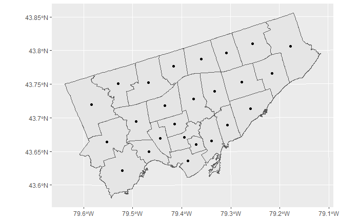

```r
#Visualize centroids using ggplot
ggplot() +
  geom_sf(data = wards) +
  geom_sf(data = wards_cent)
```

### 4.0 Plotting Data

Displaying data visually within R can be accomplished with the use of many different packages. Within this workshop we will be focusing on the powerful ggplot2 package. ggplot2 allows for the visualization of both attribute and geographic information, resulting in a very useful tool for GIS users.

#### 4.1 Charts and Graphs

Location data typically has attribute information, allowing for the creation of insightful visualization. Selecting an effective visualization is dependant on the available attributes. For further information on selecting effective visualization, refer to this [resource](https://cdn2.hubspot.net/hub/53/file-863940581-pdf/Data_Visualization_101_How_to_Design_Charts_and_Graphs.pdf) on designing graphs and charts.

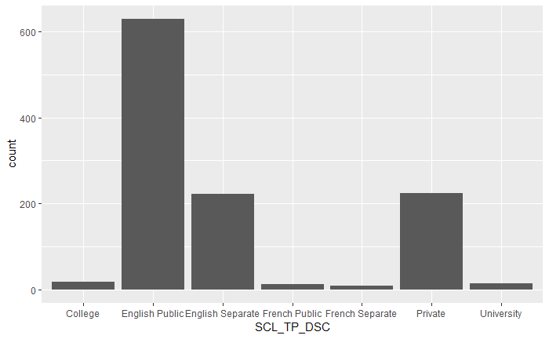

```r
#Using ggplot2 to view attribute information (bar chart)
#Visualizing the frequency of school group
ggplot(schools, aes(SCL_TP_DSC)) +
  geom_bar()
```

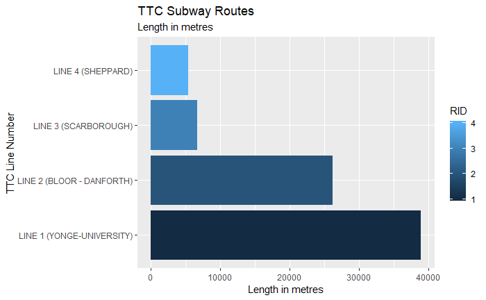

```r
#Visualizing the length of subway route length by TTC line
ggplot(subway, aes(x = ROUTE_NAME, y = as.numeric(length_m), label = 'Length in metres')) +
  geom_bar(stat = 'identity', aes(fill = RID)) +
  labs(subtitle = "Length in metres",
  title = "TTC Subway Routes") +
  labs(x = "TTC Line Number") +
  labs(y = "Length in metres") +
  coord_flip()
```

#### 4.2 Static Maps - Simple Symbology

Maps are an effective visualization for conveying geographic information. A map can server numerous purposes and can range in complexity. In many cases a basic map will suffice when initially exploring a dataset. The following examples illustrate how to display points, lines and polygons within ggplot2.

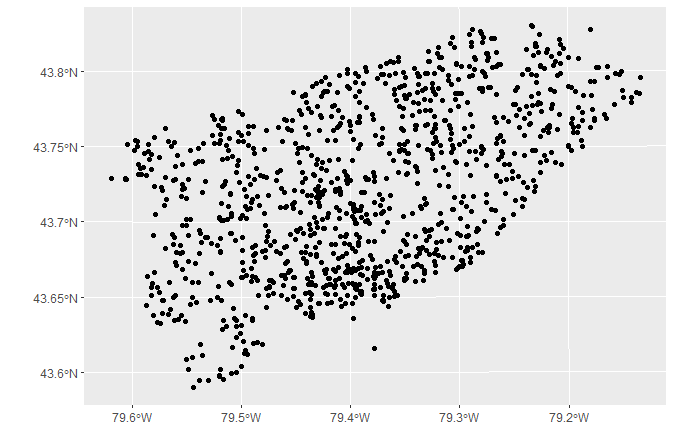

```r
#Plot point vector using ggplot2
#Plot without symbology
ggplot(data = schools) +
  geom_sf()
```

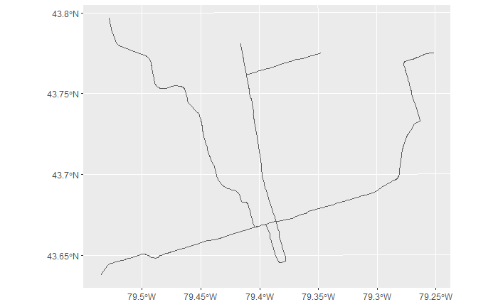

```r
#Plot line vector using ggplot2
#Plot without symbology
ggplot(data = subway) +
  geom_sf()
```

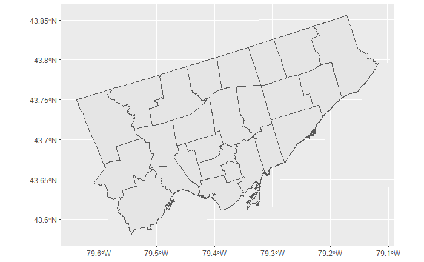

```r
#Plot polygon vector using ggplot2
#Plot without symbology
ggplot(data = wards) +
  geom_sf()
```

#### 4.3 Static Maps - Custom Symbology

##### 4.3.1 Static Maps - Custom Symbology: Colours

*Symbology - colour by text*

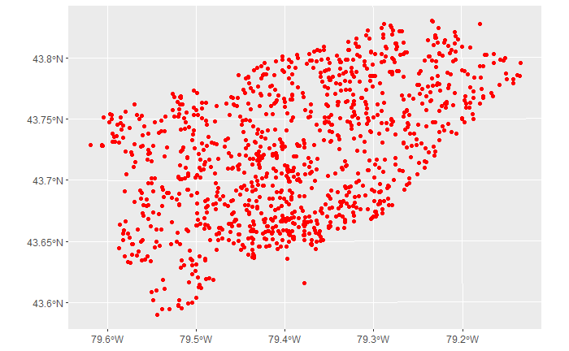

```r
#Map setting the color using color text
#Map schools
ggplot(data = schools) +
  geom_sf(color = "red")
```

*Symbology - colour by value*

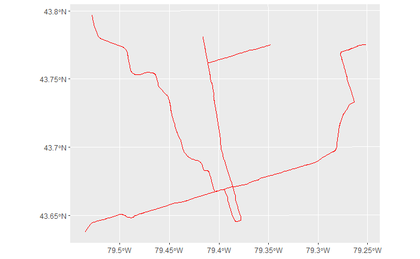

```r
#Map setting the color using hex code
#Map subway
ggplot(data = subway) +
  geom_sf(color = "#FF0000")
```

*Symbology - colour by attribute*

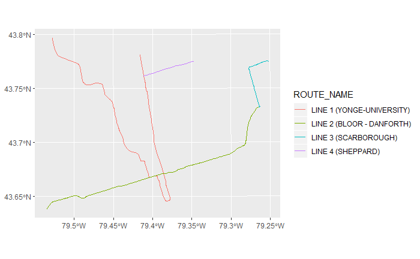

```r
#Map setting the color based on attribute values
#Map subway lines
ggplot(data = subway) +
  geom_sf(aes(color = ROUTE_NAME), show.legend = "line")
```

```r
#The show.legend = "line" piece changes the legend symbology from polygons to line. Replacing "line" to "point" will use points in the legend
```

*Symbology - polygon fill*

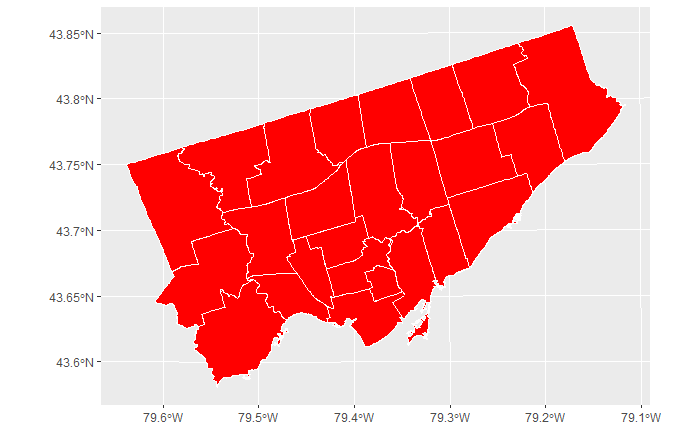

```r
#Map setting the color using color text
#Map wards
ggplot(data = wards) +
  geom_sf(fill = "red", color = "white")
```

```r
# fill controls the internal polygon colour; color controls the outline polygon colour
```

##### 4.3.2 Static Maps - Custom Symbology: Transparency

Transparceny is an effective technique when diplaying datasets with a significant amount of data. Transparency can be applied with there is a need to layer where data points overlap each other, or when layers are stacked, or to visually deprioritize one layer over another.

*Symbology - point transparency*

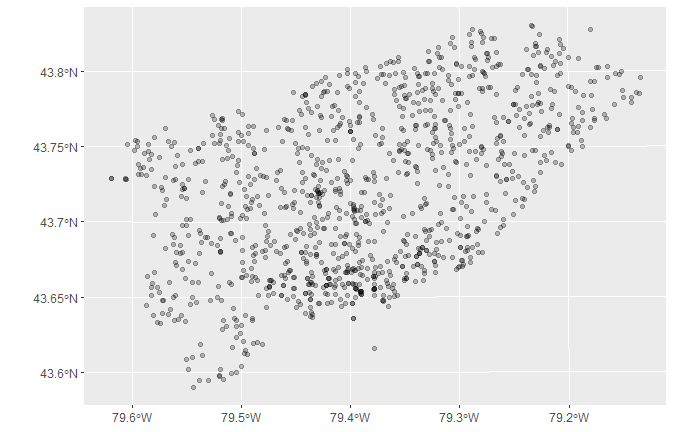

```r
#Map setting the transparceny of a point layer
#Map schools
ggplot(data = schools) +
  geom_sf(alpha = 0.25)
```

```r
#Alpha is the means for controlling transparency. Values from 1 to 0 are used to set the transparency level, with 0 being fully transparent and 1 having no transparency.
```

*Symbology - polygon transparency*

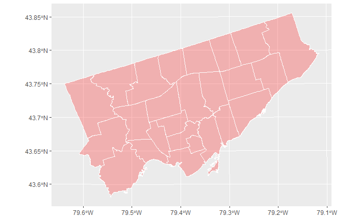

```r
#Map setting the transparceny of a polygon
#Map wards
ggplot(data = wards) +
  geom_sf(alpha = 0.25, fill = "red", color = "white")
```

```r
#Alpha is the means for controlling transparency. Values from 1 to 0 are used to set the transparency level, with 0 being fully transparent and 1 having no transparency.
```

##### 4.3.3 Static Maps - Custom Symbology: Sizes

Modifying the size of an object can be useful in many scenarios, such as illustrating importance, or ensuring features are visible.

*Symbology - static sizes*

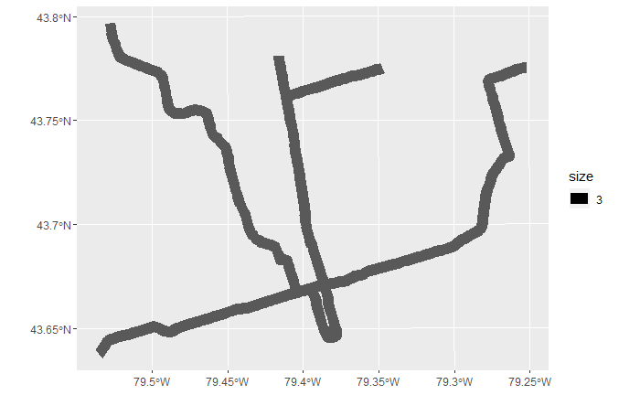

```r
#Map setting the visual size (width) of the lines using a static value
#Map subways
ggplot(data = subway) +
  geom_sf(aes(size = 3), show.legend = "line")
```

```r
#The show.legend = "line" piece changes the legend symbology from polygons to line. Replacing "line" to "point" will use points in the legend
```

*Symbology - sizes by attribute*

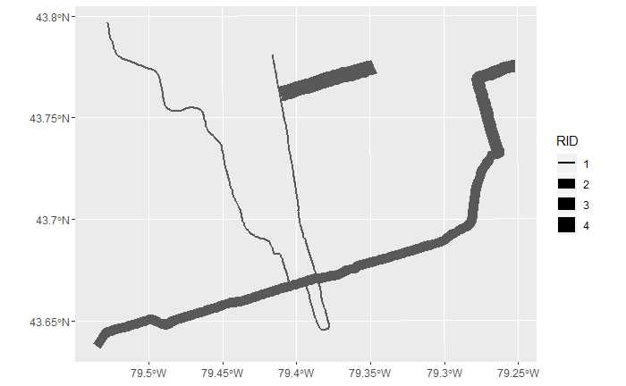

```r
#Map setting the visual size (width) of the lines using an attribute value
#Map subways
ggplot(data = subway) +
  geom_sf(aes(size = RID), show.legend = "line")
```

```r
#The show.legend = "line" piece changes the legend symbology from polygons to line. Replacing "line" to "point" will use points in the legend
```

##### 4.3.4 Static Maps - Custom Symbology: Labels

Visualizations are a source of media to convey information that would be too complex for written text. The addition of labels to a visualization can improve the communication, providing context to the visualization.

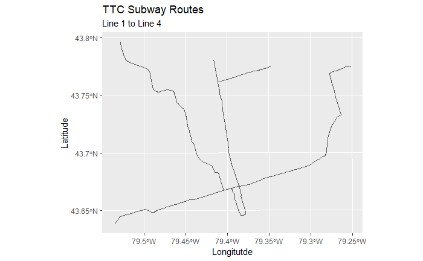

```r
ggplot() +
  geom_sf(data = subway) +
  labs(title = "TTC Subway Routes",      #using labs function to add the plot title
       subtitle = "Line 1 to Line 4") +  #using labs function to add a plot subtitle
  labs(x = "Longitutde") +               #using labs function to add a label on the x-axis
  labs(y = "Latitude")                   #using labs function to add a label on the y-axis
```

##### 4.3.5 Static Maps - Custom Symbology: Multiple vectors in one map

Rarely within location data analytics are visualizations created representing a single dataset. Typically multiple datasets are used in conjunction to illustrate the complexity of the analysis.

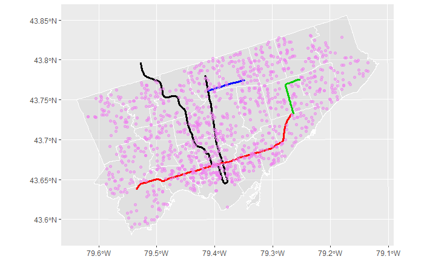

```r
#Map with point, line and polygon vector together
ggplot() +
  geom_sf(data = wards, alpha = 0.25, fill = "grey", color = "white") +
  geom_sf(data = subway, color = subway$RID, size = 1.25) +
  geom_sf(data = schools, color = "violet", alpha = 0.5)
```

### 5.0 Geoprocessing

A significant component to location data analytics is intermediate stage, typically consisting of generating new datasets from existing data that will support analysis. There are many different geoprocessing operations, with varying parametres. This section will focus on one geoprocessing task that will be used in the next section, spatial analysis. For more geoprocessing examples see the [sf cheatsheet](https://github.com/ryangarnett/cheatsheat/blob/master/cheatsheetSFPackage.pdf).

*Buffering*

```r
#Buffer
#Buffer subway lines - not storing geometry
st_buffer(subway, 1000)
```

```
Simple feature collection with 4 features and 4 fields
geometry type:  POLYGON
dimension:      XY
bbox:           xmin: 300927.8 ymin: 4831875 xmax: 325823 ymax: 4851535
epsg (SRID):    NA
proj4string:    +proj=tmerc +lat_0=0 +lon_0=-79.5 +k=0.9999 +x_0=304800 +y_0=0 +datum=NAD27 +units=m +no_defs
  OBJECTID                ROUTE_NAME RID                       geometry    length_m
1    53420 LINE 1 (YONGE-UNIVERSITY)   1 POLYGON ((303600.7 4850208,... 38894.062 m
2    53421 LINE 2 (BLOOR - DANFORTH)   2 POLYGON ((301261.9 4833636,... 26192.382 m
3    53422      LINE 3 (SCARBOROUGH)   3 POLYGON ((321750.5 4847255,...  6622.532 m
4    53423         LINE 4 (SHEPPARD)   4 POLYGON ((311751.3 4847603,...  5366.335 m
```

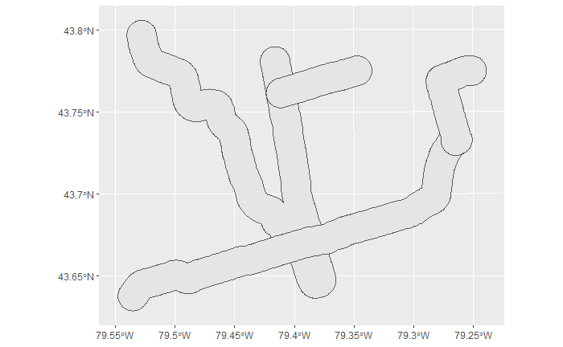

```r
#Buffer subway lines - storing geometry
subway_buffer <- st_buffer(subway, 1000)
#Map of buffered subway lines
ggplot() +
  geom_sf(data = subway_buffer)
```

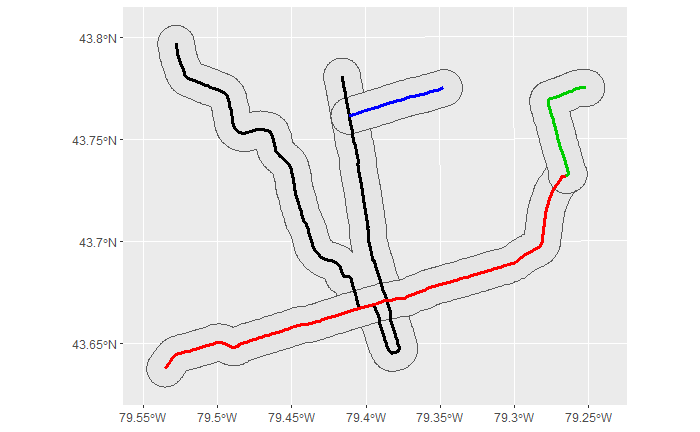

```r
#Map of buffered subway lines with subway lines
ggplot() +
  geom_sf(data = subway_buffer) +
  geom_sf(data = subway, color = subway$RID, size = 1.25)
```

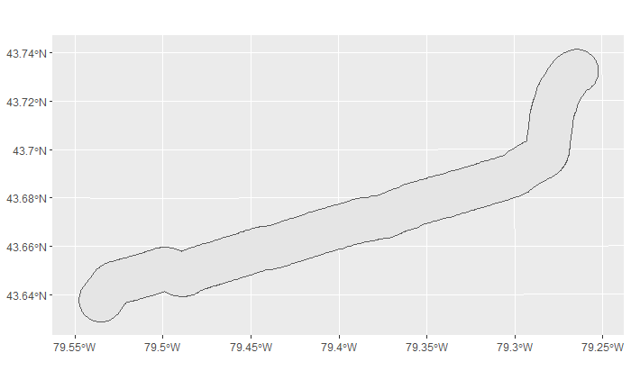

```r
#Buffer selected record
#Buffer subway line #2 (Bloor - Danforth)
subway_buffer_line2 <- subway %>%
  filter(RID == 2) %>%
  st_buffer(1000)
#Map of buffered subway line 2 (Bloor -Danforth)
ggplot() +
  geom_sf(data = subway_buffer_line2)
```

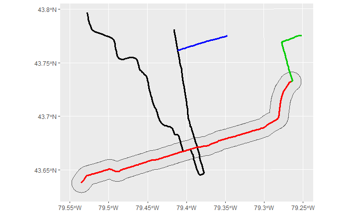

```r
#Map of buffered subway line 2 (Bloor -Danforth) with subway lines
ggplot() +
  geom_sf(data = subway_buffer_line2) +
  geom_sf(data = subway, color=subway$RID, size = 1.25)
```

#### 5.1 Spatial Analysis

Location data analytics is rooted in spatial analysis, leveraging tools and techniques for understanding the physical environment. Spatial analysis typically requires multiple datasets, and utilizes a combination of geoprocessing and analysis techniques. This section will focus on one spatial analysis problem – identifying the schools that are within 1km of a subway line. The example will provide two alternatives: one where new data layers are created, and a second where all analysis is performed in the computers memory. For more spatial analysis examples see the [sf cheatsheet](https://github.com/ryangarnett/cheatsheat/blob/master/cheatsheetSFPackage.pdf).

```r
#Count points within polygon(s) - st_intersection
#Requires geometry to be created
count(st_intersection(schools, subway_buffer))
```

```
attribute variables are assumed to be spatially constant throughout all geometries
```

```
Simple feature collection with 1 feature and 1 field
geometry type:  MULTIPOINT
dimension:      XY
bbox:           xmin: 301470.1 ymin: 4833389 xmax: 325324.6 ymax: 4849450
epsg (SRID):    NA
proj4string:    +proj=tmerc +lat_0=0 +lon_0=-79.5 +k=0.9999 +x_0=304800 +y_0=0 +datum=NAD27 +units=m +no_defs
```

| n | geometry |
| --- | --- |
| 404 |  |

```r
#Points in polygons - st_intersection
schoolsInBuffer <- st_intersection(schools, subway_buffer)
```

```
attribute variables are assumed to be spatially constant throughout all geometries
```

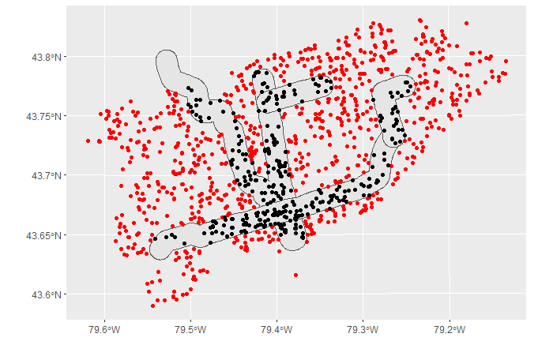

```r
#Map points that intersect with subway buffer
ggplot() +
  geom_sf(data = subway_buffer) +
  geom_sf(data = schools, color = "red") +
  geom_sf(data = schoolsInBuffer, color = "black")
```

*Analysis without creating objects*

```r
#Count points within polygon(s) - st_intersection
#Does not require geometry to be created
count(st_intersection(schools, st_buffer(subway, 1000)))
```

```
attribute variables are assumed to be spatially constant throughout all geometries
```

```
Simple feature collection with 1 feature and 1 field
geometry type:  MULTIPOINT
dimension:      XY
bbox:           xmin: 301470.1 ymin: 4833389 xmax: 325324.6 ymax: 4849450
epsg (SRID):    NA
proj4string:    +proj=tmerc +lat_0=0 +lon_0=-79.5 +k=0.9999 +x_0=304800 +y_0=0 +datum=NAD27 +units=m +no_defs
```

| n | geometry |
| --- | --- |
| 404 |  |

```
attribute variables are assumed to be spatially constant throughout all geometries
```

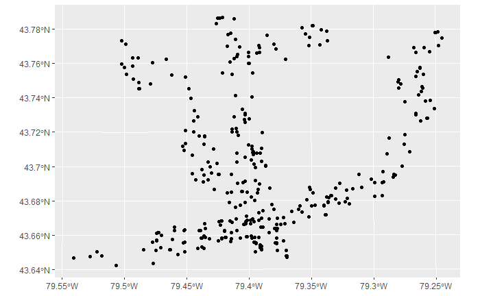

```r
#Map points that intersect with subway buffer
#Does not require geometry to be created
ggplot() +
  geom_sf(data = st_intersection(schools, st_buffer(subway, 1000)))
```

### 6.0 Resources

[GIS in R](http://www.nickeubank.com/gis-in-r/)

[Spatial Data in R: New Directions](https://edzer.github.io/UseR2017/)

[Geocomputation with R](https://geocompr.robinlovelace.net/)

[R for Data Science](http://r4ds.had.co.nz/)

[ggplot2 book](http://moderngraphics11.pbworks.com/f/ggplot2-Book09hWickham.pdf)

ggplot2 Colours Cookbook

[Data visualization 101](https://cdn2.hubspot.net/hub/53/file-863940581-pdf/Data_Visualization_101_How_to_Design_Charts_and_Graphs.pdf)

[sf cheatsheet](https://github.com/ryangarnett/cheatsheat/blob/master/cheatsheetSFPackage.pdf)